# 1. Introduction

### In this file we're going to load the dataset and have a look at it. We'll look at

#### 1. Is the data clean?

#### 2. Observations that might be outliers

#### 3. Predictor and target variable distribution

#### 4. Dataset size

### We're doing this to both to inform our choice of model/evalutation criteria and make sure that the data we're training with high quality data.

# 2. Libraries

```python
import pandas as pd
import numpy as np
import matplotlib.pyplot as plt
import seaborn as sn
```

# 3. Load the data

```python
# no header names in the dataset, but we can get them from the UCI website
hd_col_names = ["age","sex","cp","trestbps","chol","fbs","restecg","thalach","exang","oldpeak","slope","ca","thal","num"]

len(hd_col_names)

# also looks like "?" is used as an NA value
hd_na_values = ["?"]
```

```python
hd_data = pd.read_csv('../data/processed.cleveland.data',names = hd_col_names, na_values = hd_na_values)
```

# 4. Basic checks

### 4.1 The shape

```python
hd_data
```

|  | age | sex | cp | trestbps | chol | fbs | restecg | thalach | exang | oldpeak | slope | ca | thal | num |
| --- | --- | --- | --- | --- | --- | --- | --- | --- | --- | --- | --- | --- | --- | --- |
| 0 | 63.0 | 1.0 | 1.0 | 145.0 | 233.0 | 1.0 | 2.0 | 150.0 | 0.0 | 2.3 | 3.0 | 0.0 | 6.0 | 0 |
| 1 | 67.0 | 1.0 | 4.0 | 160.0 | 286.0 | 0.0 | 2.0 | 108.0 | 1.0 | 1.5 | 2.0 | 3.0 | 3.0 | 2 |
| 2 | 67.0 | 1.0 | 4.0 | 120.0 | 229.0 | 0.0 | 2.0 | 129.0 | 1.0 | 2.6 | 2.0 | 2.0 | 7.0 | 1 |
| 3 | 37.0 | 1.0 | 3.0 | 130.0 | 250.0 | 0.0 | 0.0 | 187.0 | 0.0 | 3.5 | 3.0 | 0.0 | 3.0 | 0 |
| 4 | 41.0 | 0.0 | 2.0 | 130.0 | 204.0 | 0.0 | 2.0 | 172.0 | 0.0 | 1.4 | 1.0 | 0.0 | 3.0 | 0 |
| ... | ... | ... | ... | ... | ... | ... | ... | ... | ... | ... | ... | ... | ... | ... |
| 298 | 45.0 | 1.0 | 1.0 | 110.0 | 264.0 | 0.0 | 0.0 | 132.0 | 0.0 | 1.2 | 2.0 | 0.0 | 7.0 | 1 |
| 299 | 68.0 | 1.0 | 4.0 | 144.0 | 193.0 | 1.0 | 0.0 | 141.0 | 0.0 | 3.4 | 2.0 | 2.0 | 7.0 | 2 |
| 300 | 57.0 | 1.0 | 4.0 | 130.0 | 131.0 | 0.0 | 0.0 | 115.0 | 1.0 | 1.2 | 2.0 | 1.0 | 7.0 | 3 |
| 301 | 57.0 | 0.0 | 2.0 | 130.0 | 236.0 | 0.0 | 2.0 | 174.0 | 0.0 | 0.0 | 2.0 | 1.0 | 3.0 | 1 |
| 302 | 38.0 | 1.0 | 3.0 | 138.0 | 175.0 | 0.0 | 0.0 | 173.0 | 0.0 | 0.0 | 1.0 | NaN | 3.0 | 0 |

303 rows × 14 columns

```python
hd_data.shape # 303 rows and 14 cols as we expected
```

```
(303, 14)
```

### 4.2 Count and find the cols with missing values

```python
hd_data.isnull().sum().sum()
```

```
6
```

```python
hd_data.isnull().sum()
```

```
age         0
sex         0
cp          0
trestbps    0
chol        0
fbs         0
restecg     0
thalach     0
exang       0
oldpeak     0
slope       0
ca          4
thal        2
num         0
dtype: int64
```

### We'll deal with missing values in a bit. Some models can't deal with missing data, but some implementations can. There are various strategies to deal with these missing values, depending on if they are missing at random or not

### 4.3 Check the dtypes - check that pandas has infered the correct data type for each column

```python
hd_data.dtypes
```

```
age         float64
sex         float64
cp          float64
trestbps    float64
chol        float64
fbs         float64
restecg     float64
thalach     float64
exang       float64
oldpeak     float64
slope       float64
ca          float64
thal        float64
num           int64
dtype: object
```

### This is not correct. We'll build a dictionary of the appropriate dtyes and re-load the file. There's good description on the UCI website with what the data types should be for most of them, but we might have to have a quick google on some of the more ambigous ones

### 4.4 Set the correct data types, using UCI and https://www.hindawi.com/journals/cmmm/2017/8272091/

```python
hd_dtypes = {'age': np.float64, 'sex': bool, 'cp': object, 'trestbps': np.float64, 'chol': np.float64,
             'fbs': bool, 'restecg': object, 'thalach': np.float64, 'exang': bool, 'oldpeak': np.float64,
             'slope': 'category', 'ca': np.float64, 'thal': object,'num':np.int64}

# we'll convert age and ca to int afterwards - so that we can do it in a "safe" way
```

### 4.5 Reload using our new hd_dtypes dictionary

```python
hd_data = pd.read_csv('../data/processed.cleveland.data',names = hd_col_names, na_values = hd_na_values, dtype = hd_dtypes)
```

```python
hd_data.shape # 303 rows and 14 cols as we expected
```

```
(303, 14)
```

### 4.6 recheck dtypes

```python
hd_data.dtypes
```

```
age          float64
sex             bool
cp            object
trestbps     float64
chol         float64
fbs             bool
restecg       object
thalach      float64
exang           bool
oldpeak      float64
slope       category
ca           float64
thal          object
num            int64
dtype: object
```

### 4.7 manually convert age and ca to int64

```python
hd_data["age"] = hd_data["age"].astype(np.int64)
```

```python
hd_data["ca"] = hd_data["ca"].astype('Int64') # pandas Int64 can hold NaNs, np.int64 can't
```

```python
hd_data.dtypes
```

```
age            int64
sex             bool
cp            object
trestbps     float64
chol         float64
fbs             bool
restecg       object
thalach      float64
exang           bool
oldpeak      float64
slope       category
ca             Int64
thal          object
num            int64
dtype: object
```

```python
hd_data.isnull().sum() # check we haven't coerced a NaN to a zero, or something weird like that - looks the same
```

```
age         0
sex         0
cp          0
trestbps    0
chol        0
fbs         0
restecg     0
thalach     0
exang       0
oldpeak     0
slope       0
ca          4
thal        2
num         0
dtype: int64
```

# 5. Predictor distributions

#### We'll also use this to see if we can just discard observations with missing values - if they're common looking observations, we can bin them, if not we'll have to do better

### 5.1 Age

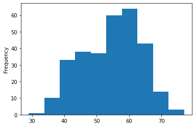

```python
ax = hd_data["age"].plot.hist(bins=10, alpha=1.0,density=0)
```

#### People younger than 40 or older than 65 don't seem to be well represented in our dataset

### 5.2 Sex

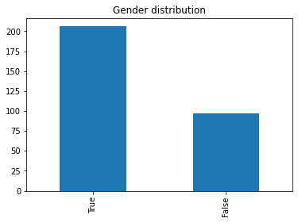

```python
df_fa = hd_data['sex'].value_counts()

df_fa.plot(kind='bar',y='Gender distribution', title = 'Gender distribution')
```

#### More men than women

### 5.3 Chest pain type (cp)

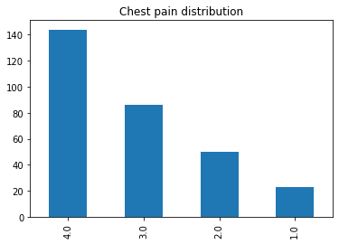

```python
df_fa = hd_data['cp'].value_counts()

df_fa.plot(kind='bar', title = 'Chest pain distribution')
```

### 5.4 Resting bp on admission (trestbps)

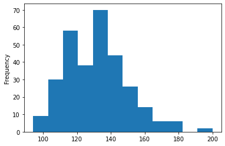

```python
ax = hd_data["trestbps"].plot.hist(bins=12, alpha=1.0,density=0)
```

```python
print(hd_data["trestbps"].mean())
print(hd_data["trestbps"].std())
```

```
131.68976897689768
17.59974772958769
```

#### Consider removing anything over 190

### 5.5 Cholesterol (chol)

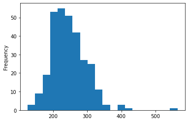

```python
ax = hd_data["chol"].plot.hist(bins=20, alpha=1.0,density=0)
```

#### Some data right out at the extremes - consider removing them

```python
print(hd_data["chol"].mean())
print(hd_data["chol"].std())
```

```
246.69306930693068
51.77691754263704
```

#### Looks vaguely normal - If we define an extreme value as three standard deviations from the mean (rarer than 99.7%) we should discard anything over 400

### 5.6 Fasting blood sugar (fbs)

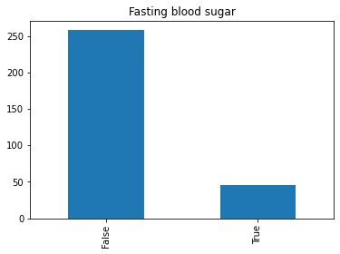

```python
df_fa = hd_data['fbs'].value_counts()

df_fa.plot(kind='bar', title = 'Fasting blood sugar')
```

#### True events much less common

### 5.7 Resting ecg result (restecg)

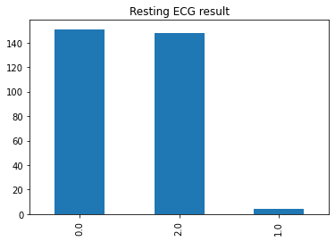

```python
df_fa = hd_data['restecg'].value_counts()

df_fa.plot(kind='bar', title = 'Resting ECG result')
```

### 5.8 Maximum heart rate (thalach)

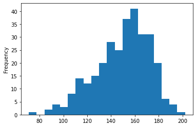

```python
ax = hd_data["thalach"].plot.hist(bins=20, alpha=1.0,density=0)
```

```python
print(hd_data["thalach"].mean())
print(hd_data["thalach"].std())
```

```
149.6072607260726
22.875003276980376
```

#### Consider dropping values less than 90, again skewed but mosly normal

### 5.9 Exercise enduced angina (exang)

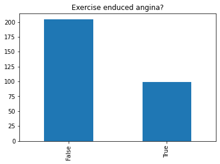

```python
df_fa = hd_data['exang'].value_counts()

df_fa.plot(kind='bar', title = 'Exercise enduced angina?')
```

### 5.10 ST depression induced by exercise relative to rest (oldpeak)

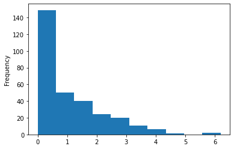

```python
ax = hd_data["oldpeak"].plot.hist(bins=10, alpha=1,density=0)
```

### 5.11 the slope of the peak exercise ST segment (slope)

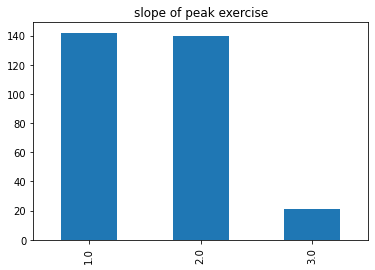

```python
df_fa = hd_data['slope'].value_counts()

df_fa.plot(kind='bar', title = 'slope of peak exercise')
```

### 5.12 number of major vessels colored by flourosopy (ca)

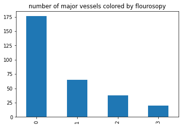

```python
df_fa = hd_data['ca'].value_counts()

df_fa.plot(kind='bar', title = 'number of major vessels colored by flourosopy')
```

### 5.13 thal

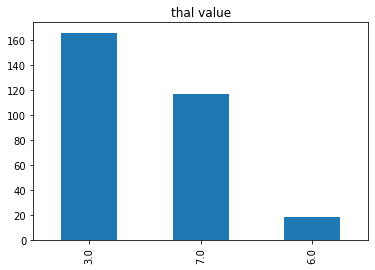

```python
df_fa = hd_data['thal'].value_counts()

df_fa.plot(kind='bar', title = 'thal value')
```

### 5.14 target - diagnosis of heart disease, angiographic disease status (num)

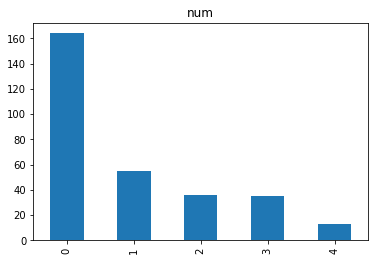

```python
df_fa = hd_data['num'].value_counts()

df_fa.plot(kind='bar', title = 'num')
```

#### Considering how little data we have, we should consider bunching this up into 0 and 1+, where we consider disesase to be 1+

# 6 Disposing of outliers and missing data

### 6.1 Let's look at the rows with NAs in them

```python
na_rows = hd_data[ (hd_data["ca"].isnull() == True) | (hd_data["thal"].isnull() == True) ].shape[0]
print(na_rows)
```

```
6
```

### 6.2 Count the outliers

```python
#restbps > 190
#hol > 400
#halach < 90
#oldpeak in 5 or 6

# from our exploration above....
```

```python
outlier_rows = hd_data[ (hd_data["trestbps"]> 190) | (hd_data["chol"]> 400) | (hd_data["thalach"]<90) | (hd_data["oldpeak"] > 4)].shape[0]
print(outlier_rows)
```

```
13
```

#### This would mean removing 19 observations from our dataset,

```python
(1 - ((hd_data.shape[0] - (na_rows+outlier_rows) )/ hd_data.shape[0]))*100
```

```
6.270627062706269
```

#### Losing 6 percent of our observations, which isn't great - we'll save a cutdown version and compare it

### 6.3 drop the outlier and na rows

```python
na_row_idxs = hd_data[ (hd_data["ca"].isnull() == True) | (hd_data["thal"].isnull() == True) ].index
hd_data_2 = hd_data.drop(na_row_idxs)
hd_data_2.shape
```

```
(297, 14)
```

```python
outlier_row_idxs = hd_data[ (hd_data["trestbps"]> 190) | (hd_data["chol"]> 400) | (hd_data["thalach"]<90) | (hd_data["oldpeak"] > 4)].index
hd_data_3 = hd_data_2.drop(outlier_row_idxs)
hd_data_3.shape
```

```
(284, 14)
```

```python
hd_data_3
```

|  | age | sex | cp | trestbps | chol | fbs | restecg | thalach | exang | oldpeak | slope | ca | thal | num |
| --- | --- | --- | --- | --- | --- | --- | --- | --- | --- | --- | --- | --- | --- | --- |
| 0 | 63 | True | 1.0 | 145.0 | 233.0 | True | 2.0 | 150.0 | False | 2.3 | 3.0 | 0 | 6.0 | 0 |
| 1 | 67 | True | 4.0 | 160.0 | 286.0 | False | 2.0 | 108.0 | True | 1.5 | 2.0 | 3 | 3.0 | 2 |
| 2 | 67 | True | 4.0 | 120.0 | 229.0 | False | 2.0 | 129.0 | True | 2.6 | 2.0 | 2 | 7.0 | 1 |
| 3 | 37 | True | 3.0 | 130.0 | 250.0 | False | 0.0 | 187.0 | False | 3.5 | 3.0 | 0 | 3.0 | 0 |
| 4 | 41 | False | 2.0 | 130.0 | 204.0 | False | 2.0 | 172.0 | False | 1.4 | 1.0 | 0 | 3.0 | 0 |
| ... | ... | ... | ... | ... | ... | ... | ... | ... | ... | ... | ... | ... | ... | ... |
| 297 | 57 | False | 4.0 | 140.0 | 241.0 | False | 0.0 | 123.0 | True | 0.2 | 2.0 | 0 | 7.0 | 1 |
| 298 | 45 | True | 1.0 | 110.0 | 264.0 | False | 0.0 | 132.0 | False | 1.2 | 2.0 | 0 | 7.0 | 1 |
| 299 | 68 | True | 4.0 | 144.0 | 193.0 | True | 0.0 | 141.0 | False | 3.4 | 2.0 | 2 | 7.0 | 2 |
| 300 | 57 | True | 4.0 | 130.0 | 131.0 | False | 0.0 | 115.0 | True | 1.2 | 2.0 | 1 | 7.0 | 3 |
| 301 | 57 | False | 2.0 | 130.0 | 236.0 | False | 2.0 | 174.0 | False | 0.0 | 2.0 | 1 | 3.0 | 1 |

284 rows × 14 columns

```python
hd_data_4 = hd_data_3.reset_index(drop = True)# reset the index
```

```python
hd_data_4
```

|  | age | sex | cp | trestbps | chol | fbs | restecg | thalach | exang | oldpeak | slope | ca | thal | num |
| --- | --- | --- | --- | --- | --- | --- | --- | --- | --- | --- | --- | --- | --- | --- |
| 0 | 63 | True | 1.0 | 145.0 | 233.0 | True | 2.0 | 150.0 | False | 2.3 | 3.0 | 0 | 6.0 | 0 |
| 1 | 67 | True | 4.0 | 160.0 | 286.0 | False | 2.0 | 108.0 | True | 1.5 | 2.0 | 3 | 3.0 | 2 |
| 2 | 67 | True | 4.0 | 120.0 | 229.0 | False | 2.0 | 129.0 | True | 2.6 | 2.0 | 2 | 7.0 | 1 |
| 3 | 37 | True | 3.0 | 130.0 | 250.0 | False | 0.0 | 187.0 | False | 3.5 | 3.0 | 0 | 3.0 | 0 |
| 4 | 41 | False | 2.0 | 130.0 | 204.0 | False | 2.0 | 172.0 | False | 1.4 | 1.0 | 0 | 3.0 | 0 |
| ... | ... | ... | ... | ... | ... | ... | ... | ... | ... | ... | ... | ... | ... | ... |
| 279 | 57 | False | 4.0 | 140.0 | 241.0 | False | 0.0 | 123.0 | True | 0.2 | 2.0 | 0 | 7.0 | 1 |
| 280 | 45 | True | 1.0 | 110.0 | 264.0 | False | 0.0 | 132.0 | False | 1.2 | 2.0 | 0 | 7.0 | 1 |
| 281 | 68 | True | 4.0 | 144.0 | 193.0 | True | 0.0 | 141.0 | False | 3.4 | 2.0 | 2 | 7.0 | 2 |
| 282 | 57 | True | 4.0 | 130.0 | 131.0 | False | 0.0 | 115.0 | True | 1.2 | 2.0 | 1 | 7.0 | 3 |
| 283 | 57 | False | 2.0 | 130.0 | 236.0 | False | 2.0 | 174.0 | False | 0.0 | 2.0 | 1 | 3.0 | 1 |

284 rows × 14 columns

### 6.4 Agglomerate the num target feature into 0 and 1 (including 1,2,3,4). This is because we have such a small amount of data, that it'll make our job even harder if we try and cut the data anymore

```python
hd_data_5 = hd_data_4
```

```python
hd_data_5.loc[hd_data_5['num'] > 1, 'num'] = 1
```

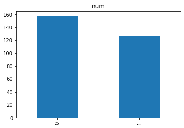

```python
df_fa = hd_data_5['num'].value_counts()

df_fa.plot(kind='bar', title = 'num')
```

# 7. Predictivity - naive feature selection via one way analysis

### 7.1 Age

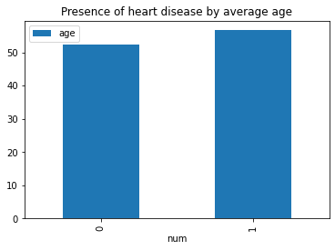

```python
df_pred_age = hd_data_5[['age','num']]

df_pred_age = df_pred_age.groupby('num').agg('mean')

df_pred_age.plot(kind='bar',y='age',title = "Presence of heart disease by average age")
```

#### weakly predictive

### 7.2 sex

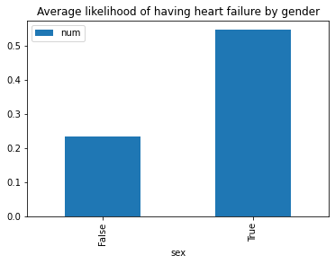

```python
df_pred_sex = hd_data_5[['sex','num']]

df_pred_sex = df_pred_sex.groupby('sex').agg('mean')

df_pred_sex

df_pred_sex.plot(kind='bar',y='num',title = "Average likelihood of having heart failure by gender")
```

#### If you're a woman in the dataset, you have an apriori chance of 0.25 of having heart failure, if you're a man a 0.5 chance

### 7.3 CP

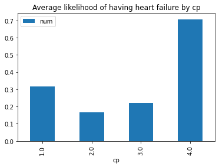

```python
df_pred_cp = hd_data_5[['cp','num']]

df_pred_cp = df_pred_cp.groupby('cp').agg('mean')

#df_pred_sex

df_pred_cp.plot(kind='bar',y='num',title = "Average likelihood of having heart failure by cp")
```

#### Consider agglomerating levels 1,2 and 3

### 7.4 trestbps

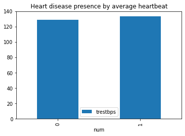

```python
df_pred_trestbp = hd_data_5[['trestbps','num']]

df_pred_trestbp = df_pred_trestbp.groupby('num').agg('mean')

df_pred_trestbp.plot(kind='bar',y='trestbps',title = "Heart disease presence by average heartbeat")
```

#### Looks like this isn't predictive, might be given interactions, but leave out in one model

### 7.5 - cholesterol

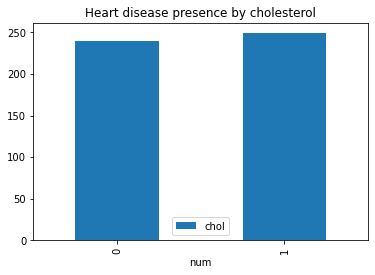

```python
df_pred_chol = hd_data_5[['chol','num']]

df_pred_chol = df_pred_chol.groupby('num').agg('mean')

df_pred_chol.plot(kind='bar',y='chol',title = "Heart disease presence by cholesterol")
```

#### doesn't seem predictive

### 7.6 fasting blood sugar

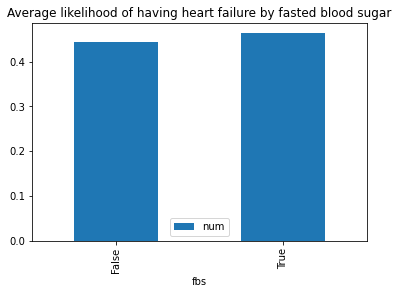

```python
df_pred_fbs = hd_data_5[['fbs','num']]

df_pred_fbs = df_pred_fbs.groupby('fbs').agg('mean')

#df_pred_sex

df_pred_fbs.plot(kind='bar',y='num',title = "Average likelihood of having heart failure by fasted blood sugar")
```

#### very little in it

### 7.7 restecg

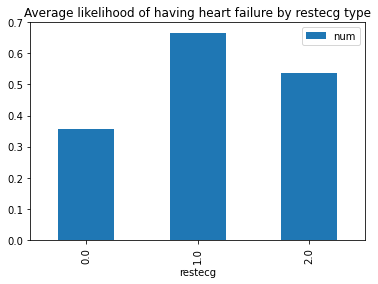

```python
df_pred_restecg = hd_data_5[['restecg','num']]

df_pred_restecg = df_pred_restecg.groupby('restecg').agg('mean')

#df_pred_sex

df_pred_restecg.plot(kind='bar',y='num',title = "Average likelihood of having heart failure by restecg type")
```

#### Predictive - consider agglomerating levels 1 and 2

### 7.8 thalach - maximum heart rate achieved

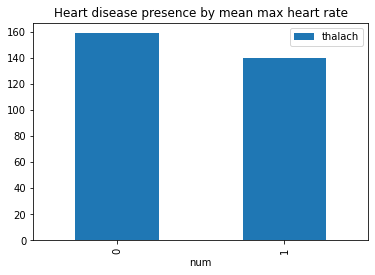

```python
df_pred_thalach = hd_data_5[['thalach','num']]

df_pred_thalach = df_pred_thalach.groupby('num').agg('mean')

df_pred_thalach.plot(kind='bar',y='thalach',title = "Heart disease presence by mean max heart rate")
```

#### some predictive power

### 7.9 exang - exercise induced angina

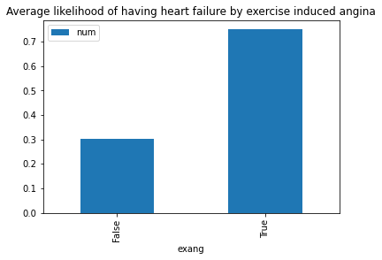

```python
df_pred_exang = hd_data_5[['exang','num']]

df_pred_exang = df_pred_exang.groupby('exang').agg('mean')

#df_pred_sex

df_pred_exang.plot(kind='bar',y='num',title = "Average likelihood of having heart failure by exercise induced angina")
```

#### keep, predictive

### 7.10 oldpeak

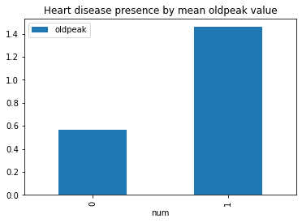

```python
df_pred_oldpeak = hd_data_5[['oldpeak','num']]

df_pred_oldpeak = df_pred_oldpeak.groupby('num').agg('mean')

df_pred_oldpeak.plot(kind='bar',y='oldpeak',title = "Heart disease presence by mean oldpeak value")
```

### 7.11 slope

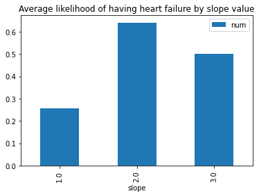

```python
df_pred_slope = hd_data_5[['slope','num']]

df_pred_slope = df_pred_slope.groupby('slope').agg('mean')

df_pred_slope

df_pred_slope.plot(kind='bar',y='num',title = "Average likelihood of having heart failure by slope value")
```

#### predictive, consider agglomerating levels 2 and 3

### 7.12 ca

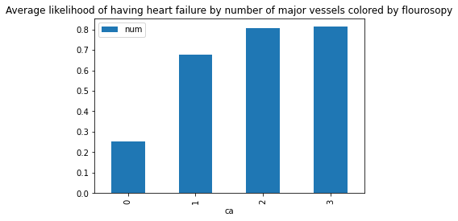

```python
df_pred_ca = hd_data_5[['ca','num']]

df_pred_ca = df_pred_ca.groupby('ca').agg('mean')

df_pred_ca.plot(kind='bar',y='num',title = "Average likelihood of having heart failure by number of major vessels colored by flourosopy")
```

#### predictive, but again consider agglomerating levels 1,2,3

### 7.13 thal

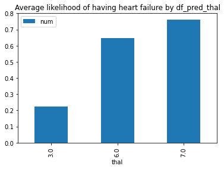

```python
df_pred_thal = hd_data_5[['thal','num']]

df_pred_thal = df_pred_thal.groupby('thal').agg('mean')

df_pred_thal.plot(kind='bar',y='num',title = "Average likelihood of having heart failure by df_pred_thal")
```

#### predictive, but again consider agglomerating levels 6 and 7

# 8. Agglomerating levels

### Given we have so little data it might make sense to agglomerate categories that are similar in terms of heart disease risk. This will mean fewer categorical variables in a GLM or fewer splits in a tree based model. There will be very little data per level variable or per split. In addition categorical variables with more than two levels easily get lost inside tree based methods.

### Before we agglomerate we should have a look at the variances in each level to see if it's plausable to perform the agglomeratiion

### Agglomeration candidates are based upon that which we discovered above, specifically we'll look at:

```python
#1. cp
#2. rest_ecg
#3. slope
#4. ca
#5. thal
```

### When we model we'll produce three models:

### 1. Throw everything at it and let it "learn" the correct features, disposing of poor quality features during training

### 2. A second in which we supply hand tuned features.

### 3. A third in which we cut down the features based upon our eyeballing of the data

### We'll produce three datasets for these three models. We'll call the modifications we've made so far the "kitchen_sink" dataset/model , the "hand_tuned" dataset/model and hand_tuned_feature_selected dataset/model

```python
kitchen_sink_data = hd_data_5.copy(deep=True)
hand_tuned_data = hd_data_5.copy(deep=True)
```

### 8.1 CP

```python
df_pred_cp = hd_data_5[['cp','num']]

df_pred_cp_mean = df_pred_cp.groupby('cp').agg('mean')

df_pred_cp_std = df_pred_cp.groupby('cp').agg('std')

df_pred_cp_count = df_pred_cp.groupby('cp').agg('count')

print(df_pred_cp_count)
```

```
     num
cp
1.0   22
2.0   48
3.0   81
4.0  133
```

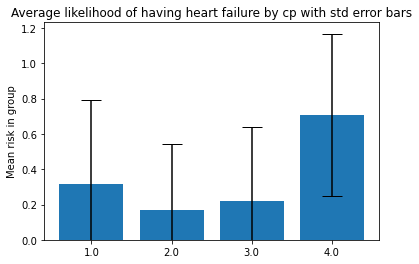

```python
levels_ = ['1.0','2.0','3.0','4.0']
x_ticks = np.arange(len(levels_))
mean_risk = df_pred_cp_mean["num"]
error = df_pred_cp_std["num"]

fig, ax = plt.subplots()
ax.bar(x_ticks, mean_risk, yerr=error, align='center', alpha=1, ecolor='black', capsize=10)
ax.set_ylabel('Mean risk in group')
ax.set_xticks(x_ticks)
ax.set_xticklabels(levels_)
ax.set_title('Average likelihood of having heart failure by cp with std error bars')
ax.axis(ymin = 0)


plt.show()
```

#### Agglomerate 1,2 and 3

```python
hand_tuned_data.loc[hand_tuned_data['cp'] != "4.0", 'cp'] = "1_3"
hand_tuned_data.loc[hand_tuned_data['cp'] == "4.0", 'cp'] = "4"
```

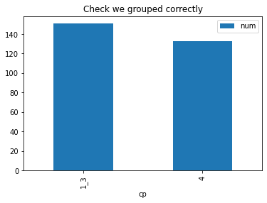

```python
df_fa = hand_tuned_data[['cp','num']]

df_fa = df_fa.groupby('cp').agg('count')

df_fa.plot(kind='bar',y='num',title = "Check we grouped correctly")
```

### 8.2 rest ecg

```python
df_pred_ecg = hd_data_5[['restecg','num']]

df_pred_ecg_mean = df_pred_ecg.groupby('restecg').agg('mean')

df_pred_ecg_std = df_pred_ecg.groupby('restecg').agg('std')

df_pred_ecg_count = df_pred_ecg.groupby('restecg').agg('count')

print(df_pred_ecg_count)
```

```
         num
restecg
0.0      143
1.0        3
2.0      138
```

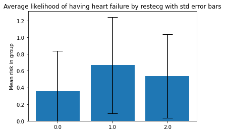

```python
levels_ = ['0.0','1.0','2.0']
x_ticks = np.arange(len(levels_))
mean_risk = df_pred_ecg_mean["num"]
error = df_pred_ecg_std["num"]

fig, ax = plt.subplots()
ax.bar(x_ticks, mean_risk, yerr=error, align='center', alpha=1, ecolor='black', capsize=10)
ax.set_ylabel('Mean risk in group')
ax.set_xticks(x_ticks)
ax.set_xticklabels(levels_)
ax.set_title('Average likelihood of having heart failure by restecg with std error bars')
ax.axis(ymin = 0)


plt.show()
```

#### Agglomerate levels 1 and 2

```python
hand_tuned_data.loc[hand_tuned_data['restecg'] != "0.0", 'restecg'] = "1_2"
hand_tuned_data.loc[hand_tuned_data['restecg'] == "0.0", 'restecg'] = "0"
```

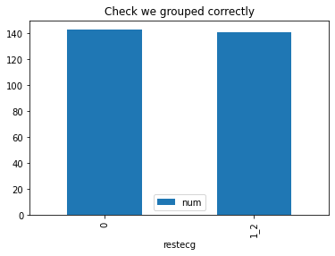

```python
df_fa = hand_tuned_data[['restecg','num']]

df_fa = df_fa.groupby('restecg').agg('count')

df_fa.plot(kind='bar',y='num',title = "Check we grouped correctly")
```

### 8.3 Slope

```python
df_pred_slope = hd_data_5[['slope','num']]

df_pred_slope_mean = df_pred_slope.groupby('slope').agg('mean')

df_pred_slope_std = df_pred_slope.groupby('slope').agg('std')

df_pred_slope_count = df_pred_slope.groupby('slope').agg('count')

print(df_pred_slope_count)
```

```
       num
slope
1.0    137
2.0    131
3.0     16
```

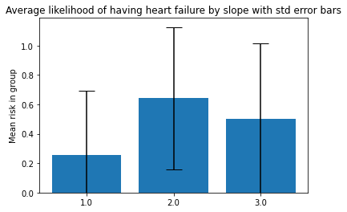

```python
levels_ = ['1.0','2.0','3.0']
x_ticks = np.arange(len(levels_))
mean_risk = df_pred_slope_mean["num"]
error = df_pred_slope_std["num"]

fig, ax = plt.subplots()
ax.bar(x_ticks, mean_risk, yerr=error, align='center', alpha=1, ecolor='black', capsize=10)
ax.set_ylabel('Mean risk in group')
ax.set_xticks(x_ticks)
ax.set_xticklabels(levels_)
ax.set_title('Average likelihood of having heart failure by slope with std error bars')
ax.axis(ymin = 0)


plt.show()
```

#### Agglomerate levels 2 and 3

```python
hand_tuned_data['slope'] = hand_tuned_data['slope'].astype(object)

hand_tuned_data.loc[hand_tuned_data['slope'] != "1.0", 'slope'] = "2_3"
hand_tuned_data.loc[hand_tuned_data['slope'] == "1.0", 'slope'] = "1"
```

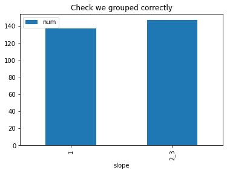

```python
df_fa = hand_tuned_data[['slope','num']]

df_fa = df_fa.groupby('slope').agg('count')

df_fa.plot(kind='bar',y='num',title = "Check we grouped correctly")
```

### 8.4 ca

```python
df_pred_ca = hd_data_5[['ca','num']]

df_pred_ca_mean = df_pred_ca.groupby('ca').agg('mean')

df_pred_ca_std = df_pred_ca.groupby('ca').agg('std')

df_pred_ca_count = df_pred_ca.groupby('ca').agg('count')

print(df_pred_ca_count)
```

```
    num
ca
0   170
1    62
2    36
3    16
```

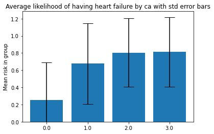

```python
levels_ = ['0.0','1.0','2.0','3.0']
x_ticks = np.arange(len(levels_))
mean_risk = df_pred_ca_mean["num"]
error = df_pred_ca_std["num"]

fig, ax = plt.subplots()
ax.bar(x_ticks, mean_risk, yerr=error, align='center', alpha=1, ecolor='black', capsize=10)
ax.set_ylabel('Mean risk in group')
ax.set_xticks(x_ticks)
ax.set_xticklabels(levels_)
ax.set_title('Average likelihood of having heart failure by ca with std error bars')
ax.axis(ymin = 0)


plt.show()
```

```python
hand_tuned_data.loc[hand_tuned_data['ca'] != 0.0, 'ca'] = 1
hand_tuned_data.loc[hand_tuned_data['ca'] == 0.0, 'ca'] = 0
```

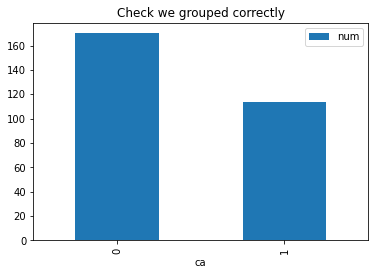

```python
df_fa = hand_tuned_data[['ca','num']]

df_fa = df_fa.groupby('ca').agg('count')

df_fa.plot(kind='bar',y='num',title = "Check we grouped correctly")
```

#### Agglomerate 1,2,3

### 8.5 Thal

```python
df_pred_thal = hd_data_5[['thal','num']]

df_pred_thal_mean = df_pred_thal.groupby('thal').agg('mean')

df_pred_thal_std = df_pred_thal.groupby('thal').agg('std')

df_pred_thal_count = df_pred_thal.groupby('thal').agg('count')

print(df_pred_thal_count)
```

```
      num
thal
3.0   162
6.0    17
7.0   105
```

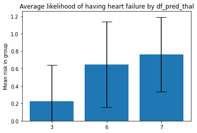

```python
levels_ = ['3','6','7']
x_ticks = np.arange(len(levels_))
mean_risk = df_pred_thal_mean["num"]
error = df_pred_thal_std["num"]

fig, ax = plt.subplots()
ax.bar(x_ticks, mean_risk, yerr=error, align='center', alpha=1, ecolor='black', capsize=10)
ax.set_ylabel('Mean risk in group')
ax.set_xticks(x_ticks)
ax.set_xticklabels(levels_)
ax.set_title('Average likelihood of having heart failure by df_pred_thal')
ax.axis(ymin = 0)


plt.show()
```

#### Large amount of overlap between 6 and 7. Also 6 only has 17 people in it. Agglomerate levels 6 and 7

```python
hand_tuned_data.loc[hand_tuned_data['thal'] != "3.0", 'thal'] = "6_7"
hand_tuned_data.loc[hand_tuned_data['thal'] == "3.0", 'thal'] = "3"
```

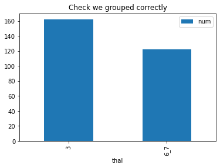

```python
df_fa = hand_tuned_data[['thal','num']]

df_fa = df_fa.groupby('thal').agg('count')

df_fa.plot(kind='bar',y='num',title = "Check we grouped correctly")
```

# 9. Correlation matrix

### Quick look at the correlation matrix before we start modelling

```python
hand_tuned_data.dtypes
```

```
age           int64
sex            bool
cp           object
trestbps    float64
chol        float64
fbs            bool
restecg      object
thalach     float64
exang          bool
oldpeak     float64
slope        object
ca            Int64
thal         object
num           int64
dtype: object
```

```python
corr = hand_tuned_data[["age","trestbps","chol","thalach","oldpeak","ca","num"]]
```

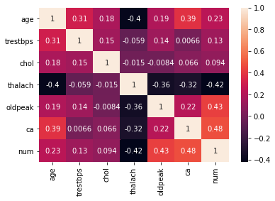

```python
corrMatrix = corr.corr()
sn.heatmap(corrMatrix, annot=True)
plt.show()
```

```python
kitchen_sink_data.dtypes
```

```
age            int64
sex             bool
cp            object
trestbps     float64
chol         float64
fbs             bool
restecg       object
thalach      float64
exang           bool
oldpeak      float64
slope       category
ca             Int64
thal          object
num            int64
dtype: object
```

```python
hand_tuned_data.dtypes
```

```
age           int64
sex            bool
cp           object
trestbps    float64
chol        float64
fbs            bool
restecg      object
thalach     float64
exang          bool
oldpeak     float64
slope        object
ca            Int64
thal         object
num           int64
dtype: object
```

```python
hand_tuned_data_feature_selected = hand_tuned_data[["age", "sex", "cp", "restecg", "thalach", "exang", "oldpeak", "slope", "ca", "thal","num"]]
```

```python
hand_tuned_data_feature_selected.dtypes
```

```
age          int64
sex           bool
cp          object
restecg     object
thalach    float64
exang         bool
oldpeak    float64
slope       object
ca           Int64
thal        object
num          int64
dtype: object
```

# 10. One hot the categorical variables

```python
kitchen_sink_data_oh = pd.get_dummies(kitchen_sink_data, columns=["sex","cp","fbs","restecg","exang","slope","thal"], prefix=["sex","cp","fbs","restecg","exang","slope","thal"] )

kitchen_sink_data_oh
```

|  | age | trestbps | chol | thalach | oldpeak | ca | num | sex_False | sex_True | cp_1.0 | ... | restecg_1.0 | restecg_2.0 | exang_False | exang_True | slope_1.0 | slope_2.0 | slope_3.0 | thal_3.0 | thal_6.0 | thal_7.0 |
| --- | --- | --- | --- | --- | --- | --- | --- | --- | --- | --- | --- | --- | --- | --- | --- | --- | --- | --- | --- | --- | --- |
| 0 | 63 | 145.0 | 233.0 | 150.0 | 2.3 | 0 | 0 | 0 | 1 | 1 | ... | 0 | 1 | 1 | 0 | 0 | 0 | 1 | 0 | 1 | 0 |
| 1 | 67 | 160.0 | 286.0 | 108.0 | 1.5 | 3 | 1 | 0 | 1 | 0 | ... | 0 | 1 | 0 | 1 | 0 | 1 | 0 | 1 | 0 | 0 |
| 2 | 67 | 120.0 | 229.0 | 129.0 | 2.6 | 2 | 1 | 0 | 1 | 0 | ... | 0 | 1 | 0 | 1 | 0 | 1 | 0 | 0 | 0 | 1 |
| 3 | 37 | 130.0 | 250.0 | 187.0 | 3.5 | 0 | 0 | 0 | 1 | 0 | ... | 0 | 0 | 1 | 0 | 0 | 0 | 1 | 1 | 0 | 0 |
| 4 | 41 | 130.0 | 204.0 | 172.0 | 1.4 | 0 | 0 | 1 | 0 | 0 | ... | 0 | 1 | 1 | 0 | 1 | 0 | 0 | 1 | 0 | 0 |
| ... | ... | ... | ... | ... | ... | ... | ... | ... | ... | ... | ... | ... | ... | ... | ... | ... | ... | ... | ... | ... | ... |
| 279 | 57 | 140.0 | 241.0 | 123.0 | 0.2 | 0 | 1 | 1 | 0 | 0 | ... | 0 | 0 | 0 | 1 | 0 | 1 | 0 | 0 | 0 | 1 |
| 280 | 45 | 110.0 | 264.0 | 132.0 | 1.2 | 0 | 1 | 0 | 1 | 1 | ... | 0 | 0 | 1 | 0 | 0 | 1 | 0 | 0 | 0 | 1 |
| 281 | 68 | 144.0 | 193.0 | 141.0 | 3.4 | 2 | 1 | 0 | 1 | 0 | ... | 0 | 0 | 1 | 0 | 0 | 1 | 0 | 0 | 0 | 1 |
| 282 | 57 | 130.0 | 131.0 | 115.0 | 1.2 | 1 | 1 | 0 | 1 | 0 | ... | 0 | 0 | 0 | 1 | 0 | 1 | 0 | 0 | 0 | 1 |
| 283 | 57 | 130.0 | 236.0 | 174.0 | 0.0 | 1 | 1 | 1 | 0 | 0 | ... | 0 | 1 | 1 | 0 | 0 | 1 | 0 | 1 | 0 | 0 |

284 rows × 26 columns

```python
hand_tuned_data_oh = pd.get_dummies(hand_tuned_data, columns=["sex","cp","fbs","restecg","exang","slope","thal"], prefix=["sex","cp","fbs","restecg","exang","slope","thal"] )

hand_tuned_data_oh
```

|  | age | trestbps | chol | thalach | oldpeak | ca | num | sex_False | sex_True | cp_1_3 | ... | fbs_False | fbs_True | restecg_0 | restecg_1_2 | exang_False | exang_True | slope_1 | slope_2_3 | thal_3 | thal_6_7 |
| --- | --- | --- | --- | --- | --- | --- | --- | --- | --- | --- | --- | --- | --- | --- | --- | --- | --- | --- | --- | --- | --- |
| 0 | 63 | 145.0 | 233.0 | 150.0 | 2.3 | 0 | 0 | 0 | 1 | 1 | ... | 0 | 1 | 0 | 1 | 1 | 0 | 0 | 1 | 0 | 1 |
| 1 | 67 | 160.0 | 286.0 | 108.0 | 1.5 | 1 | 1 | 0 | 1 | 0 | ... | 1 | 0 | 0 | 1 | 0 | 1 | 0 | 1 | 1 | 0 |
| 2 | 67 | 120.0 | 229.0 | 129.0 | 2.6 | 1 | 1 | 0 | 1 | 0 | ... | 1 | 0 | 0 | 1 | 0 | 1 | 0 | 1 | 0 | 1 |
| 3 | 37 | 130.0 | 250.0 | 187.0 | 3.5 | 0 | 0 | 0 | 1 | 1 | ... | 1 | 0 | 1 | 0 | 1 | 0 | 0 | 1 | 1 | 0 |
| 4 | 41 | 130.0 | 204.0 | 172.0 | 1.4 | 0 | 0 | 1 | 0 | 1 | ... | 1 | 0 | 0 | 1 | 1 | 0 | 1 | 0 | 1 | 0 |
| ... | ... | ... | ... | ... | ... | ... | ... | ... | ... | ... | ... | ... | ... | ... | ... | ... | ... | ... | ... | ... | ... |
| 279 | 57 | 140.0 | 241.0 | 123.0 | 0.2 | 0 | 1 | 1 | 0 | 0 | ... | 1 | 0 | 1 | 0 | 0 | 1 | 0 | 1 | 0 | 1 |
| 280 | 45 | 110.0 | 264.0 | 132.0 | 1.2 | 0 | 1 | 0 | 1 | 1 | ... | 1 | 0 | 1 | 0 | 1 | 0 | 0 | 1 | 0 | 1 |
| 281 | 68 | 144.0 | 193.0 | 141.0 | 3.4 | 1 | 1 | 0 | 1 | 0 | ... | 0 | 1 | 1 | 0 | 1 | 0 | 0 | 1 | 0 | 1 |
| 282 | 57 | 130.0 | 131.0 | 115.0 | 1.2 | 1 | 1 | 0 | 1 | 0 | ... | 1 | 0 | 1 | 0 | 0 | 1 | 0 | 1 | 0 | 1 |
| 283 | 57 | 130.0 | 236.0 | 174.0 | 0.0 | 1 | 1 | 1 | 0 | 1 | ... | 1 | 0 | 0 | 1 | 1 | 0 | 0 | 1 | 1 | 0 |

284 rows × 21 columns

```python
hand_tuned_data_feature_selected_oh = pd.get_dummies(hand_tuned_data_feature_selected, columns=["sex","cp","restecg","exang","slope","thal"], prefix=["sex","cp","restecg","exang","slope","thal"] )

hand_tuned_data_feature_selected_oh
```

|  | age | thalach | oldpeak | ca | num | sex_False | sex_True | cp_1_3 | cp_4 | restecg_0 | restecg_1_2 | exang_False | exang_True | slope_1 | slope_2_3 | thal_3 | thal_6_7 |
| --- | --- | --- | --- | --- | --- | --- | --- | --- | --- | --- | --- | --- | --- | --- | --- | --- | --- |
| 0 | 63 | 150.0 | 2.3 | 0 | 0 | 0 | 1 | 1 | 0 | 0 | 1 | 1 | 0 | 0 | 1 | 0 | 1 |
| 1 | 67 | 108.0 | 1.5 | 1 | 1 | 0 | 1 | 0 | 1 | 0 | 1 | 0 | 1 | 0 | 1 | 1 | 0 |
| 2 | 67 | 129.0 | 2.6 | 1 | 1 | 0 | 1 | 0 | 1 | 0 | 1 | 0 | 1 | 0 | 1 | 0 | 1 |
| 3 | 37 | 187.0 | 3.5 | 0 | 0 | 0 | 1 | 1 | 0 | 1 | 0 | 1 | 0 | 0 | 1 | 1 | 0 |
| 4 | 41 | 172.0 | 1.4 | 0 | 0 | 1 | 0 | 1 | 0 | 0 | 1 | 1 | 0 | 1 | 0 | 1 | 0 |
| ... | ... | ... | ... | ... | ... | ... | ... | ... | ... | ... | ... | ... | ... | ... | ... | ... | ... |
| 279 | 57 | 123.0 | 0.2 | 0 | 1 | 1 | 0 | 0 | 1 | 1 | 0 | 0 | 1 | 0 | 1 | 0 | 1 |
| 280 | 45 | 132.0 | 1.2 | 0 | 1 | 0 | 1 | 1 | 0 | 1 | 0 | 1 | 0 | 0 | 1 | 0 | 1 |
| 281 | 68 | 141.0 | 3.4 | 1 | 1 | 0 | 1 | 0 | 1 | 1 | 0 | 1 | 0 | 0 | 1 | 0 | 1 |
| 282 | 57 | 115.0 | 1.2 | 1 | 1 | 0 | 1 | 0 | 1 | 1 | 0 | 0 | 1 | 0 | 1 | 0 | 1 |
| 283 | 57 | 174.0 | 0.0 | 1 | 1 | 1 | 0 | 1 | 0 | 0 | 1 | 1 | 0 | 0 | 1 | 1 | 0 |

284 rows × 17 columns

```python
kitchen_sink_data_oh.columns
```

```
Index(['age', 'trestbps', 'chol', 'thalach', 'oldpeak', 'ca', 'num',
       'sex_False', 'sex_True', 'cp_1.0', 'cp_2.0', 'cp_3.0', 'cp_4.0',
       'fbs_False', 'fbs_True', 'restecg_0.0', 'restecg_1.0', 'restecg_2.0',
       'exang_False', 'exang_True', 'slope_1.0', 'slope_2.0', 'slope_3.0',
       'thal_3.0', 'thal_6.0', 'thal_7.0'],
      dtype='object')
```

```python
kitchen_sink_data_oh = kitchen_sink_data_oh[['age', 'trestbps', 'chol', 'thalach', 'oldpeak', 'ca',
       'sex_False', 'sex_True', 'cp_1.0', 'cp_2.0', 'cp_3.0', 'cp_4.0',
       'fbs_False', 'fbs_True', 'restecg_0.0', 'restecg_1.0', 'restecg_2.0',
       'exang_False', 'exang_True', 'slope_1.0', 'slope_2.0', 'slope_3.0',
       'thal_3.0', 'thal_6.0', 'thal_7.0','num']]
```

```python
hand_tuned_data_oh.columns
```

```
Index(['age', 'trestbps', 'chol', 'thalach', 'oldpeak', 'ca', 'num',
       'sex_False', 'sex_True', 'cp_1_3', 'cp_4', 'fbs_False', 'fbs_True',
       'restecg_0', 'restecg_1_2', 'exang_False', 'exang_True', 'slope_1',
       'slope_2_3', 'thal_3', 'thal_6_7'],
      dtype='object')
```

```python
hand_tuned_data_oh = hand_tuned_data_oh[['age', 'trestbps', 'chol', 'thalach', 'oldpeak', 'ca',
       'sex_False', 'sex_True', 'cp_1_3', 'cp_4', 'fbs_False', 'fbs_True',
       'restecg_0', 'restecg_1_2', 'exang_False', 'exang_True', 'slope_1',
       'slope_2_3', 'thal_3', 'thal_6_7','num']]
```

```python
hand_tuned_data_feature_selected_oh.columns
```

```
Index(['age', 'thalach', 'oldpeak', 'ca', 'num', 'sex_False', 'sex_True',
       'cp_1_3', 'cp_4', 'restecg_0', 'restecg_1_2', 'exang_False',
       'exang_True', 'slope_1', 'slope_2_3', 'thal_3', 'thal_6_7'],
      dtype='object')
```

```python
hand_tuned_data_feature_selected_oh = hand_tuned_data_feature_selected_oh[['age', 'thalach', 'oldpeak', 'ca', 'sex_False', 'sex_True',
       'cp_1_3', 'cp_4', 'restecg_0', 'restecg_1_2', 'exang_False',
       'exang_True', 'slope_1', 'slope_2_3', 'thal_3', 'thal_6_7',"num"]]
```

# 10. save the processed data out

```python
kitchen_sink_data_oh.to_csv('../data/cleaned/kitchen_sink.csv',sep = ',',index=False )
```

```python
hand_tuned_data_oh.to_csv('../data/cleaned/hand_tuned.csv',sep = ',',index=False)
```

```python
hand_tuned_data_feature_selected_oh.to_csv('../data/cleaned/hand_tuned_feature_selected.csv',sep = ',',index=False)
```

```python
kitchen_sink_data_oh.dtypes
```